# Assignment_3

# Melbourne Housing Data

RMarkdown Reference sheet: https://www.rstudio.com/wp-content/uploads/2015/03/rmarkdown-reference.pdf

## Introduction

The purpose of this R code is to use the Melbourne housing data in order to create a model summary of a rough price estimates around Melbourne. This project aims to simplify the modelling of housing prices by taking five independent variables:

- Rooms,
- Type of house,
- Distance from the nearest train station,
- Number of bedrooms,
- Number of Bathrooms

### Selecting variables of interest

Selecting the independent variables of interest (including price for the dependent variable)

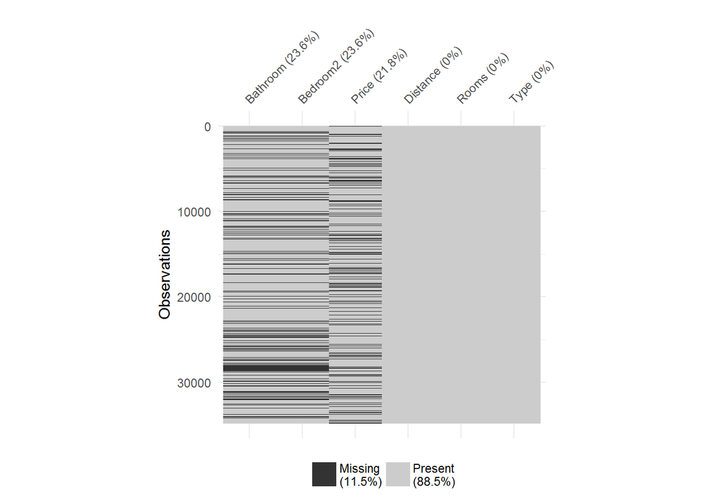

```r
## Extracting columns
houses_temp<-houses %>%
  select(Rooms, Type, Price, Distance, Bedroom2, Bathroom)

## Summarising with the missing table
vis_miss(houses_temp, sort_miss=TRUE) + theme(aspect.ratio = 1)
```

```r
##From the missing tables summary, we can conclude the following:

##- For any missing value in Bathroom, there is a missing value of Bedroom2
##- The missing values in price usually has a different row to the missing values in Bathroom/Bedroom2
##- The rest of the variables (Distance, Rooms, Type) have no missing values

## Getting a numerical summary of the data
s_miss <- miss_summary(houses_temp)
s_miss$miss_case_table
```

```
## [[1]]
## # A tibble: 4 x 3
##   n_miss_in_case n_cases pct_miss
##            <int>   <int>    <dbl>
## 1              0   20800    59.7
## 2              1    5837    16.7
## 3              2    6443    18.5
## 4              3    1777     5.10
```

```r
## This shows that a small proportion of missing values in prices overlaps with the same missing value records for bathroom and bedroom2 (n_miss_in_case = 3)
```

From the missing tables summary, we can conclude the following:

- For any missing value in Bathroom, there is a missing value of Bedroom2
- The missing values in price usually has a different row to the missing values in Bathroom/Bedroom2
- The rest of the variables (Distance, Rooms, Type) have no missing values

### Understanding the missing data

First of all, it is important to understand the variable names within the data. We asked ourselves a few questions:

- Is Rooms meant to be the same as Bedroom2? Because Bedroom2 comes from a different source so we suspect that they are both referring to bedrooms
- How many Rooms are not the same as Bedroom2?
- Furthermore, what happens if we take out all the missing values from Bedroom2? Will that give a drastically different missing summary for the tables?

```r
## Is Rooms meant to be the same as Bedroom2? Because Bedroom2 comes from a different source so we suspect that they are both referring to bedrooms

first_q <- houses %>%
  filter(Rooms==Bedroom2)
nrow(first_q)
```

```
## [1] 25692
```

```r
## Proportion of equal values
nrow(first_q) / nrow(houses)
```

```
## [1] 0.7370686
```

```r
## How many Rooms are not the same as Bedroom2?
second_q <- houses%>%
  filter(Rooms!=Bedroom2)
nrow(second_q)
```

```
## [1] 948
```

```r
## Proportion of non-equal values
nrow(second_q) / nrow(houses)
```

```
## [1] 0.02719683
```

```r
## Furthermore, what happens if we take out all the missing values from Bedroom2? Will that give a drastically different missing summary for the tables?
houses_filt<-houses %>%
  filter(!is.na(Bedroom2)) %>%
  select(Rooms, Type, Price, Distance, Bedroom2, Bathroom)

filt_summary <- miss_summary(houses_filt)
filt_summary$miss_case_table
```

```
## [[1]]
## # A tibble: 3 x 3
##   n_miss_in_case n_cases pct_miss
##            <int>   <int>    <dbl>
## 1              0   20800  78.1
## 2              1    5837  21.9
## 3              2       3   0.0113
```

From these values, our understanding is:

- Rooms should be the same as Bedroom2 (0.737 or 73.7%)
- There is a small proportion of non-equal values (0.027 or 2.7%)
- The rest are missing values from the Bedroom2 column

Furthermore, by taking out all the records with missing values from Bedroom2, we are still left with a reasonable amount of records to model the housing prices with. Records with 2 missing values will be taken out because it is hard to impute two variables in the record and this only makes up a small proportion of cases (3 cases).

Hence, we will only be using values that are equal for both Room and Bedroom2 as a large proportion of the values are the same. This provides a stronger validation of the housing data that is provided.

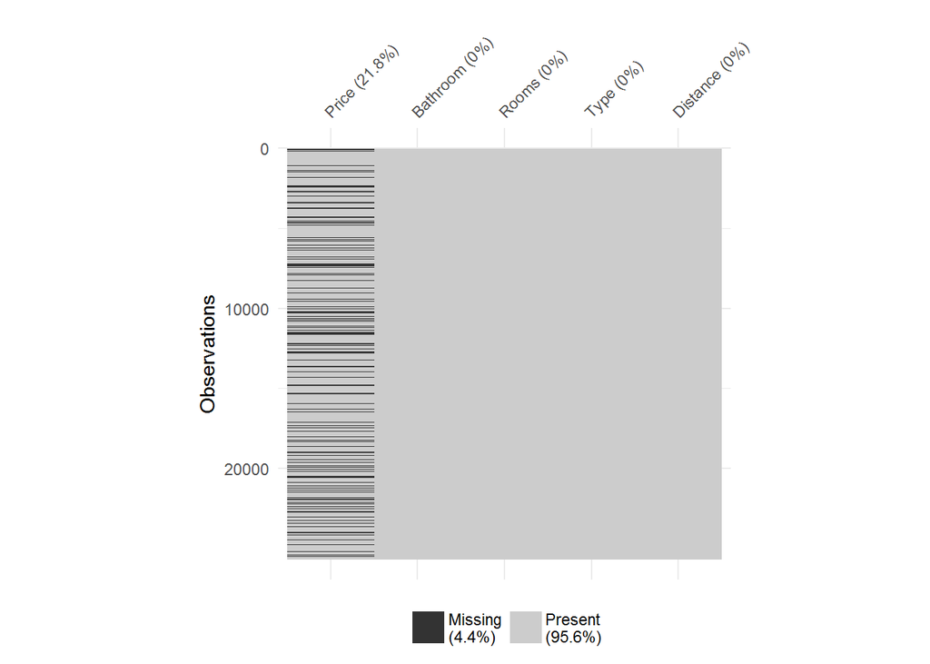

```r
## Filtering by equal values
houses_filt<-houses %>%
  filter(Rooms==Bedroom2) %>%
  filter(!(is.na(Price) & is.na(Bathroom))) %>% ## Filtering the records where there are two missing values
  select(Price, Rooms, Type, Distance, Bathroom)


## Converting all the relevant data types to numeric instead of a categorical variable
houses_filt <- houses_filt %>%
  mutate(Rooms =  as.numeric(Rooms))%>%
  mutate(Price = as.numeric(Price)) %>%
  mutate(Distance = as.numeric(Distance)) %>%
  mutate(Bathroom = as.numeric(Bathroom))
##mutate(Bedroom2 = as.numeric(Bedroom2))%>%

## Missing summary
s_miss2 <- miss_summary(houses_filt)
vis_miss(houses_filt, sort_miss=TRUE) + theme(aspect.ratio = 1)
```

```r
s_miss2$miss_case_table
```

```
## [[1]]
## # A tibble: 2 x 3
##   n_miss_in_case n_cases pct_miss
##            <int>   <int>    <dbl>
## 1              0   20079     78.2
## 2              1    5610     21.8
```

As seen, the data is now cleaner to work with. Also, as Rooms and Bedroom2 are equal, they are essentially the same data hence there is perfect collinearity between the two columns. Hence, Bedroom2 is dropped out from the regression of housing price.

```r
summary(houses_filt)
```

```
##      Price              Rooms            Type              Distance
##  Min.   :   85000   Min.   : 1.000   Length:25689       Min.   : 0.00
##  1st Qu.:  655000   1st Qu.: 2.000   Class :character   1st Qu.: 6.40
##  Median :  905000   Median : 3.000   Mode  :character   Median :10.40
##  Mean   : 1082403   Mean   : 3.087                      Mean   :11.37
##  3rd Qu.: 1325000   3rd Qu.: 4.000                      3rd Qu.:14.20
##  Max.   :11200000   Max.   :16.000                      Max.   :48.10
##  NA's   :5604
##     Bathroom
##  Min.   :0.000
##  1st Qu.:1.000
##  Median :2.000
##  Mean   :1.619
##  3rd Qu.:2.000
##  Max.   :9.000
##  NA's   :6
```

### Understanding the relationship between variables

We now investgiate the relationship between the independent and dependent variables. This includes understanding the linear or non-linearities within the data set while exploring the residuals.

```r
##knitr::opts_chunk$set(echo = TRUE)

houses_filt <- houses_filt %>%
  filter(Rooms<10) %>%
  filter(Bathroom<5) %>% ## Arbitary numbers
  filter(Rooms!=0 & !is.na(Rooms)) %>%
  filter(Bathroom!= 0 & !is.na(Bathroom)) ## Not many records that have this

houses_training <- houses_filt %>%
  filter(!is.na(Price)) %>% ##%>% ## To create the regression variables
  mutate(Price_1 = log10(Price))

##  mutate(Rooms = log10(Rooms))

houses_testing <- houses_filt %>%
  filter(is.na(Price)) ##%>%  ## To model the prices
##  mutate(Rooms = log10(Rooms))

houses_predict <- houses_testing


## First Model
##----------------------------------------------------------------------
##house_modA <- lm(Price ~ Type + Distance + Rooms + Bathroom - 1,
##             data = houses_training)
house_modA <- lm(Price_1 ~ Type + Distance + Rooms + Bathroom - 1, data = houses_training)
modelA <- glance(house_modA)
modelA
```

```
##   r.squared adj.r.squared     sigma statistic p.value df   logLik
## 1 0.9993258     0.9993256 0.1552172   4939187       0  6 8882.827
##         AIC       BIC deviance df.residual
## 1 -17751.65 -17696.33  481.703       19994
```

```r
## Second Model
##----------------------------------------------------------------------
##house_modB <- lm(Price ~ Type + Bathroom + Distance + Rooms + Type*Bathroom*Distance + Type*Rooms*Distance + ##Distance*Bathroom*Rooms -1,
##                 data = houses_training)
house_modB <- lm(Price_1 ~ Type + Distance + Rooms + Bathroom + Type*Bathroom*Distance + Type*Rooms*Distance + Distance*Bathroom*Rooms -1, data = houses_training)
model_B <- glance(house_modB)
model_B
```

```
##   r.squared adj.r.squared     sigma statistic p.value df   logLik
## 1 0.9993625     0.9993619 0.1509797   1566156       0 20 9443.429
##         AIC       BIC deviance df.residual
## 1 -18844.86 -18678.89 455.4416       19980
```

```r
## Third Model
##----------------------------------------------------------------------
##house_modC <- lm(Price ~  Type + Bathroom + Distance + Rooms +  Bathroom*Rooms + Type*Rooms +
##                 + Type*Distance + Bathroom*Distance + Rooms*Distance -1,
##                 data = houses_training)
house_modC <- lm(Price_1 ~  Type + Distance + Rooms + Bathroom +
                 + Type*Distance + Bathroom*Distance + Rooms*Distance -1, data = houses_training)
model_C <- glance(house_modC)
model_C
```

```
##   r.squared adj.r.squared     sigma statistic p.value df   logLik
## 1 0.9993496     0.9993493 0.1524609   3071707       0 10 9243.173
##         AIC       BIC deviance df.residual
## 1 -18464.35 -18377.41 464.6541       19990
```

```r
## As seen, all 3 models (linear and interactive variables) have roughly the same R squared value.


houses_predict$Price_1 <- predict(house_modB, data.frame(houses_testing))

mutate(houses_predict, Price = 10^Price_1)
```

```
## # A tibble: 5,559 x 6
##       Price Rooms Type  Distance Bathroom Price_1
##       <dbl> <dbl> <chr>    <dbl>    <dbl>   <dbl>
##  1 1067009.    2. h         2.50       1.    6.03
##  2 1097745.    3. u         2.50       2.    6.04
##  3  764065.    2. u         2.50       2.    5.88
##  4 1067009.    2. h         2.50       1.    6.03
##  5 1097745.    3. u         2.50       2.    6.04
##  6 1566720.    3. h         2.50       2.    6.19
##  7  887234.    3. h        13.5        1.    5.95
##  8 1043940.    2. h         3.30       1.    6.02
##  9 1227156.    3. h         3.30       1.    6.09
## 10 1227156.    3. h         3.30       1.    6.09
## # ... with 5,549 more rows
```

```r
houses_all <- rbind(houses_training, houses_predict)


##houses_predict <- houses_predict%>%
##  mutate(Rooms = 10^(Rooms))
```

### Understanding the model

3 models have been made and tested against each other. The price variable has been log transformed in order to increase the R squared value while also decreasing the standard deviations of the residuals. This is because without the log transformation, the residuals does not become normally distributed as it easily reaches 10-20 standard deviations away from zero. With the log transformation, the majority of the residuals fluctuate around +/- 2 standard deviations. Furthermore, the R squared value is misleading as there are lots of independent variables that have been added to the equation (including the interactive variables), hence the R squared value might not be indicative of the real performance of the model. The same goes with Adjusted R squared as it has its own flaws as well.

### Plotting the fitted vs. original values

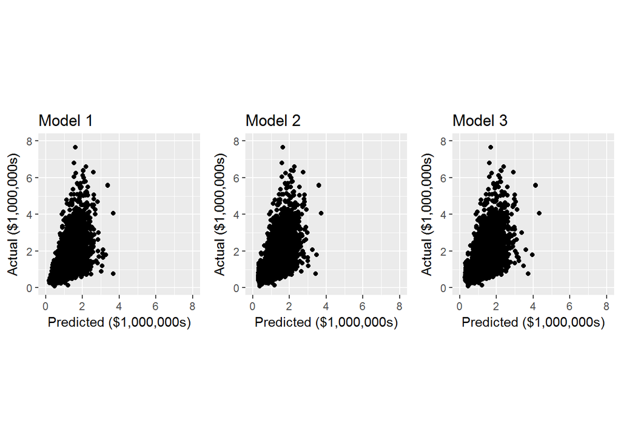

```r
## Analysing the original vs. the fitted values
## This is done for all 3 models

mod1_a2 <- augment(house_modA, houses_training)
mod2_a2 <- augment(house_modB, houses_training)
mod3_a2 <- augment(house_modC, houses_training)
p1 <- ggplot(mod1_a2, aes(x=(10^.fitted)/10^6, y=Price/10^6)) +
  geom_point() + ggtitle("Model 1")+ theme(aspect.ratio = 1) +
  xlab("Predicted ($1,000,000s)") + ylab("Actual ($1,000,000s)") +
scale_x_continuous(limits = c(0, 8)) + scale_y_continuous(limits = c(0, 8))

p2 <- ggplot(mod2_a2, aes(x=(10^.fitted)/10^6, y=Price/10^6)) +
  geom_point() + ggtitle("Model 2")+ theme(aspect.ratio = 1) +
 xlab("Predicted ($1,000,000s)") + ylab("Actual ($1,000,000s)") +
  scale_x_continuous(limits = c(0, 8)) + scale_y_continuous(limits = c(0, 8))

p3 <- ggplot(mod3_a2, aes(x=(10^.fitted)/10^6, y=Price/10^6)) +
  geom_point() + ggtitle("Model 3") + theme(aspect.ratio = 1) +
 xlab("Predicted ($1,000,000s)") + ylab("Actual ($1,000,000s)")+
  scale_x_continuous(limits = c(0, 8)) + scale_y_continuous(limits = c(0, 8))

grid.arrange(p1, p2, p3, ncol=3)
```

Furthermore, the plots of the fitted vs. the original values provides an indication that the model is prone to under-predicting the actual price. This might be because the variables that we are using does not capture the entire regression on the price variable as there could be other factors that have been omitted for the modelling of the Melbourne house price. Hence, the chosen independent variables does not capture the entire fluctuation of the housing prices.

### Analysis of the residuals

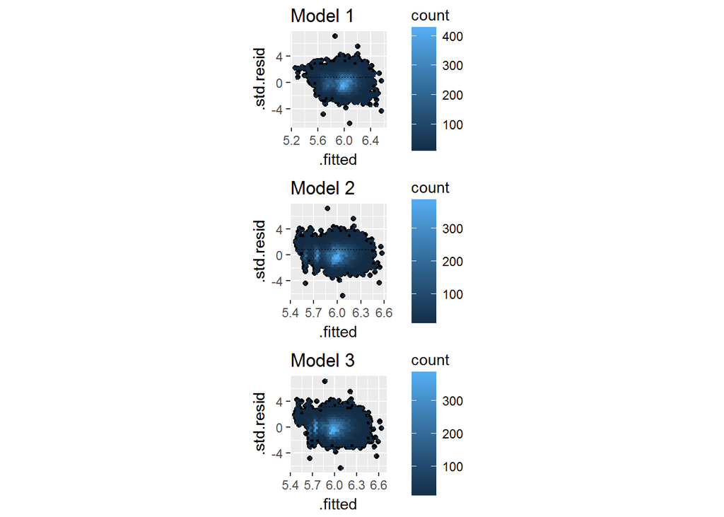

```r
## Analyising the standard deviations for residuals against fitted

p1 <- ggplot(mod1_a2, aes(x=.fitted, y=.std.resid)) +
  geom_point() + ggtitle("Model 1")+ geom_hex() + theme(aspect.ratio = 1)
p2 <- ggplot(mod2_a2, aes(x=.fitted, y=.std.resid)) +
  geom_point() + ggtitle("Model 2")+ geom_hex() + theme(aspect.ratio = 1)
p3 <- ggplot(mod3_a2, aes(x=.fitted, y=.std.resid)) +
  geom_point() + ggtitle("Model 3") + geom_hex()+ theme(aspect.ratio = 1)
grid.arrange(p1, p2, p3, ncol=1)
```

The residuals highlights that the model performs fairly well as the majority of the residuals fluctuates between +/- 2 std devs. Although there are some data points that are fluctuating between +/- 4 standard deviations, this only highlights that the model has a longer tails compared to the normal distribution.

## Plots of the independent variables

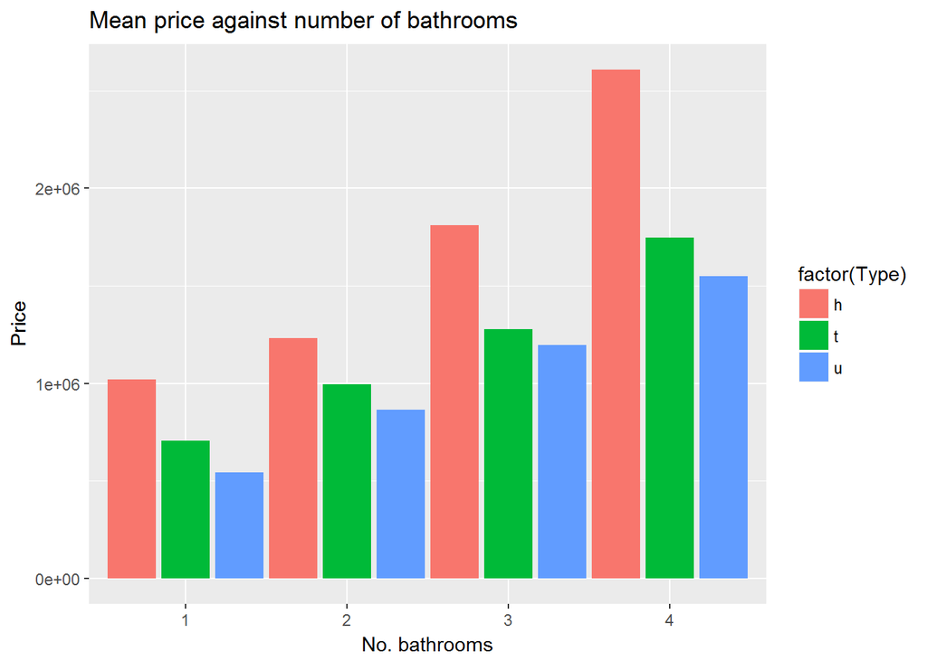

```r
##plotting the average price for then number of bathrooms for each type of building
ggplot(houses_all, aes(x=factor(Bathroom), y=Price, fill=factor(Type))) + stat_summary(fun.y="mean", geom="bar",position=position_dodge(1)) + ggtitle("Mean price against number of bathrooms") + labs(x = "No. bathrooms")
```

The general trend of the type of property are the following:

- houses are worth more than townhouses which are worth more than units for the same number of bathrooms on average.
- the more bathrooms a property has, the higher its price.
- the difference between house prices compared to townhall is more than the difference between townhalls compared to units for all levels of bathroom.

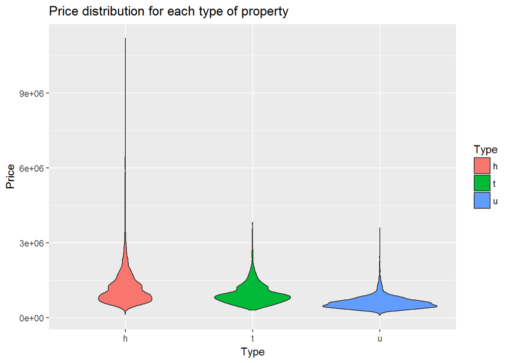

```r
##plotting the distrubtion of house prices based on Type alone
ggplot(data=houses_all, aes(x=Type, y=Price, fill=Type)) +geom_violin()+ ggtitle("Price distribution for each type of property")
```

- Units have the least price spread, followed by townhouses with houses having the most price variance.
- Houses has a larger outlier which should be taken out of the model as it will skew the model.

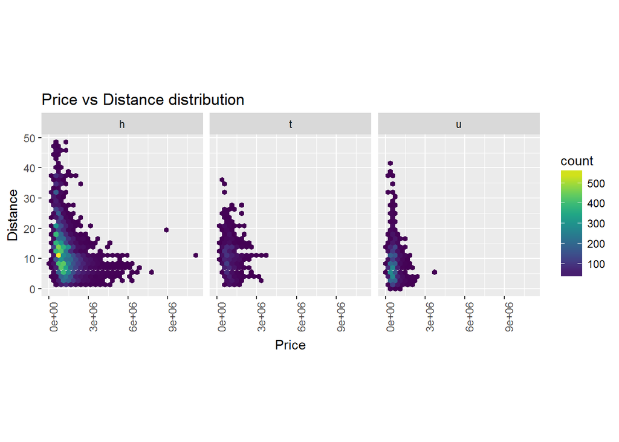

```r
##Plotting the distance against price to see the relationship for each different type of accomodation

ggplot(houses_all, aes(x=Price, y=Distance)) +
  geom_hex() +
  scale_fill_viridis()+facet_grid(~Type) + theme(aspect.ratio = 1)+ theme(axis.text.x = element_text(angle = 90, hjust = 1))+ ggtitle("Price vs Distance distribution")
```

The hex distribution graph reveals that the price of houses has the most variation but also the most data points. This may be due to the multitude of external factors such as nearby schools and ammenities or proximity to major roads has on the prices of houses. Units and townhouses are typically built in convenient locations close to ammentities and transport and hence there is less price fluctuation.

## Conclusion

```r
## This is the chosen model to predict house prices. It uses interactive variables for each distance against each independent variable.
summary(house_modC)
```

```
##
## Call:
## lm(formula = Price_1 ~ Type + Distance + Rooms + Bathroom + +Type *
##     Distance + Bathroom * Distance + Rooms * Distance - 1, data = houses_training)
##
## Residuals:
##      Min       1Q   Median       3Q      Max
## -0.96682 -0.10621 -0.00502  0.09961  1.08290
##
## Coefficients:
##                     Estimate Std. Error t value Pr(>|t|)
## Typeh              5.7672710  0.0090723 635.701  < 2e-16 ***
## Typet              5.6004230  0.0118217 473.739  < 2e-16 ***
## Typeu              5.4841822  0.0073344 747.736  < 2e-16 ***
## Distance          -0.0065008  0.0007424  -8.756  < 2e-16 ***
## Rooms              0.0914277  0.0033091  27.629  < 2e-16 ***
## Bathroom           0.0936696  0.0041233  22.717  < 2e-16 ***
## Typet:Distance     0.0063328  0.0008292   7.637 2.32e-14 ***
## Typeu:Distance     0.0092235  0.0006308  14.623  < 2e-16 ***
## Distance:Bathroom -0.0015888  0.0003141  -5.059 4.26e-07 ***
## Distance:Rooms    -0.0019822  0.0002611  -7.592 3.28e-14 ***
## ---
## Signif. codes:  0 '***' 0.001 '**' 0.01 '*' 0.05 '.' 0.1 ' ' 1
##
## Residual standard error: 0.1525 on 19990 degrees of freedom
## Multiple R-squared:  0.9993, Adjusted R-squared:  0.9993
## F-statistic: 3.072e+06 on 10 and 19990 DF,  p-value: < 2.2e-16
```

Furthermore, the modelling of the house prices was complex as it was difficult to understand which source of information was correct for the number of rooms. Hence, the Bedroom2 variable was taken out after finding the records which had matching Rooms with Bedroom2. Lastly, the intercept was taken out of the equation as it does not make sense for a house to have no rooms, bathrooms etc. when regressing for the house price. This boosted the R squared value (although not shown in this report) from 0.41 to 0.85 initially.

It should be noted that housing prices is a complex, volatile science. Two identical houses next door to eachother may sell for different amounts based on seemingly neglible issues such as a house number. It is important to note that a house/property is worth whatever somebody is willing to sell and it is difficult to capture the maximum value a property may hold to an individual.